[figure not shown]

MBA EM JORNALISMO DE DADOS  
Introdução à linguagem Python  
Rodolfo Viana

# AULA 2 — CONTROLE DE FLUXO COM *IF* E *WHILE*

Nesta aula veremos:

1. Controle de fluxo com *if*
1. *if*
2. *if*-*else*
3. *if*-*elif*-*else*
2. Controle de fluxo com *while*

# Controle de fluxo com *if*

Até o momento, estamos escrevendo códigos que são executados numa estrutura fixa: de cima para baixo, linha a linha. Exemplo:

```python
nome = input("Digite seu nome: ")
ano = input("Digite o ano de nascimento: ")
idade = 2023 - int(ano)
print("Bom dia, {}. Você tem ou terá {} anos em 2023.".format(nome, str(idade)))
```

```
Digite seu nome: Rodolfo
Digite o ano de nascimento: 1981
Bom dia, Rodolfo. Você tem ou terá 42 anos em 2023.
```

Até aqui, nosso script processa a linha 1, depois a linha 2, depois a linha 3 e, por fim, a linha 4. Uma após a outra, sem nunca pular uma linha. É um fluxo fixo.

Mas podemos mudar isso. Podemos controlar a execução, o fluxo do script. Uma das formas é com `if`, que condiciona a execução de uma linha ao resultado de outra.

## *if*

A estrutura mais simples do controle de fluxo com `if` é assim:

```
if condicao_1:
    operacao_1 # reparem que há quatro espaços antes de `operacao_1`
```

Ou seja, em português seria algo como "se a condição 1 for `True`, realize a operação 1; se não, não realize".

Desenhando,

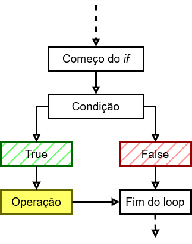

Vamos ver isso na prática:

```python
salario = 1302 * 2 # dois salários mínimos
aluguel = 1600
luz = 90
agua = 80
telefone = 99
cartao = 200
contas = aluguel + luz + agua + telefone + cartao

print("Começou o fluxo.")

if salario >= contas: # se o salário for maior ou igual ao valor das contas...
    restos = salario - contas # ...calcule quanto sobra...
    print("Consigo pagar as contas e me sobram {} reais.".format(restos)) # ...e imprima a frase com o valor

print("Acabou o fluxo.")
```

```
Começou o fluxo.
Consigo pagar as contas e me sobram 535 reais.
Acabou o fluxo.
```

No exemplo acima o cálculo de `restos` foi executado e a frase foi impressa porque `salario > contas` é `True`. Vejamos o que acontece se o salário for menor.

```python
salario = 1302 # um salário mínimo
aluguel = 1600
luz = 90
agua = 80
telefone = 99
cartao = 200
contas = aluguel + luz + agua + telefone + cartao

print("Começou o fluxo.")

if salario >= contas: # se o salário for maior ou igual ao valor das contas...
    restos = salario - contas # ...calcule quanto sobra...
    print("Consigo pagar as contas e me sobram {} reais.".format(restos)) # ...e imprima a frase com o valor

print("Acabou o fluxo.")
```

```
Começou o fluxo.
Acabou o fluxo.
```

Neste último exemplo, com apenas um salário mínimo, nem o cálculo de `restos`, nem a impressão da frase ocorreu porque `salario > contas` é `False`.

## *if*-*else*

Quando utilizamos `if`, a operação é executada apenas se a condição for `True`. Contudo, há casos em que, mesmo dando `False` queremos executar uma operação alternativa. Para isso usamos `if`-`else`. Funciona assim:

```
if condicao_1:
    operacao_1
else:
    operacao_2
```

Ou seja, em português seria algo como "se a condição 1 for `True`, realize a operação 1; se não, realize a operação 2".

Desenhando,

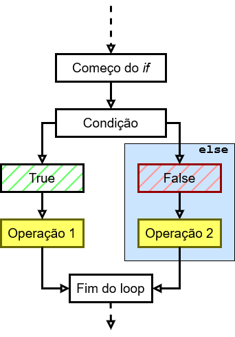

Vejamos um exemplo — primeiro, com dois salários; depois, com um salário:

```python
salario = 1302 * 2
aluguel = 1600
luz = 90
agua = 80
telefone = 99
cartao = 200
contas = aluguel + luz + agua + telefone + cartao

print("Começou o fluxo.")

if salario >= contas: # se o salário for maior ou igual ao valor das contas...
    restos = salario - contas # ...calcule quanto sobra...
    print("Consigo pagar as contas e me sobram {} reais.".format(restos)) # ...e imprima a frase com o valor
else: # se não...
    divida = contas - salario # calcule a diferença...
    print("Não consigo pagar as contas. Minha dívida é de {} reais.".format(divida)) # ...e imprima a frase com o valor


print("Acabou o fluxo.")
```

```
Começou o fluxo.
Consigo pagar as contas e me sobram 535 reais.
Acabou o fluxo.
```

```python
salario = 1302
aluguel = 1600
luz = 90
agua = 80
telefone = 99
cartao = 200
contas = aluguel + luz + agua + telefone + cartao

print("Começou o fluxo.")

if salario >= contas: # se o salário for maior ou igual ao valor das contas...
    restos = salario - contas # ...calcule quanto sobra...
    print("Consigo pagar as contas e me sobram {} reais.".format(restos)) # ...e imprima a frase com o valor
else: # se não...
    divida = contas - salario # calcule a diferença...
    print("Não consigo pagar as contas. Minha dívida é de {} reais.".format(divida)) # ...e imprima a frase com o valor


print("Acabou o fluxo.")
```

```
Começou o fluxo.
Não consigo pagar as contas. Minha dívida é de 767 reais.
Acabou o fluxo.
```

No primeiro exemplo, foi executado o bloco de operações dentro de `if`; no segundo, o bloco de operações dentro de `else`. Repare que **não houve mudanças nos códigos `if`-`else`**; o que mudou foi apenas a variável `salario`.

## *if*-*elif*-*else*

Vimos que o uso de `if`-`else` permite executar uma operação para resultado `True` e outra, distinta, para `False`. Mas e se tivermos três ou mais operações? Por exemplo:

> (1) Se a temperatura estiver acima de 30°C, devo usar protetor solar; (2) se estiver entre 20°C e 30°C, basta uma camiseta; (3) se estiver entre 10°C e 19°C, devo usar uma blusa; (4) se estiver abaixo de 10°C, preciso de jaqueta.

Repare que, na construção acima, tenho 4 condições que levam a 4 operações distintas:

| condição | operação |
| --- | --- |
| > 30 | protetor solar |
| 20-30 | camiseta |
| 10-19 | blusa |
| < 10 | jaqueta |

Como ficaria isso em Python? Bem, teríamos de ir além de `if`-`else`. Temos de usar `if`-`elif`-`else`:

```
if condicao_1:
    operacao_1
elif condicao_2:
    operacao_2
elif condicao_3:
    operacao_3
...
elif condicao_n:
    operacao_n
else:
    operacao_z
```

Ou seja, em português seria algo como "se a condição 1 for `True`, realize a operação 1; se não, veja de satisfaz a condição 2 e, se satisfazer, realize a operação 2; se não, veja de satisfaz a condição 3 e, se satisfazer, realize a operação 3 (...), se nenhuma condição for satisfeita, realize a operação z".

Desenhando,

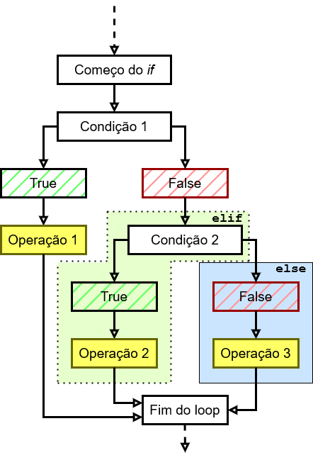

O exemplo das temperaturas em Python ficaria assim:

```python
temperatura = 28
if temperatura > 30:
    print("Devo usar protetor solar")
elif temperatura <= 30 and temperatura >= 20:
    print("Devo usar apenas uma camiseta")
elif temperatura <= 19 and temperatura >= 10:
    print("Devo usar uma blusa")
else:
    print("Devo usar uma jaqueta")
# Repare que coloquei a última condição (temperatura < 10) no
# `else`, pois é a única condição que resta dentre todas.
# Ou seja, a condição fica implícita.
```

```
Devo usar apenas uma camiseta
```

```python
temperatura = 13
if temperatura > 30:
    print("Devo usar protetor solar")
elif temperatura <= 30 and temperatura >= 20:
    print("Devo usar apenas uma camiseta")
elif temperatura <= 19 and temperatura >= 10:
    print("Devo usar uma blusa")
else:
    print("Devo usar uma jaqueta")
# Repare que coloquei a última condição (temperatura < 10) no
# `else`, pois é a única condição que resta dentre todas.
# Ou seja, a condição fica implícita.
```

```
Devo usar uma blusa
```

# Controle de fluxo com *while*

Vimos que o fluxo de um *script* pode ser controlado, que o código nem sempre precisa ter todas as suas linhas lidas. E vimos que, uma forma de controlar o fluxo, é com `if`.

Há outra forma: `while`. Diferentemente de `if`, que checa se a condição é `True` ou `False`, `while` executa a operação enquanto a condição for `True`. Sua sintaxe é assim:

```
while condicao:
    operacao
```

Um exemplo concreto:

> Tenho um micro-ônibus com nenhum passageiro e capacidade para 20 pessoas. Enquanto a lotação for menor que 20, adiciono passageiro.

Em Python, ficaria assim:

```python
passageiros = 0
lotacao = 20
while passageiros < lotacao:
    passageiros = passageiros + 1
    print("Tenho {} passageiro(s) no meu ônibus.".format(passageiros))
```

```
Tenho 1 passageiro(s) no meu ônibus.
Tenho 2 passageiro(s) no meu ônibus.
Tenho 3 passageiro(s) no meu ônibus.
Tenho 4 passageiro(s) no meu ônibus.
Tenho 5 passageiro(s) no meu ônibus.
Tenho 6 passageiro(s) no meu ônibus.
Tenho 7 passageiro(s) no meu ônibus.
Tenho 8 passageiro(s) no meu ônibus.
Tenho 9 passageiro(s) no meu ônibus.
Tenho 10 passageiro(s) no meu ônibus.
Tenho 11 passageiro(s) no meu ônibus.
Tenho 12 passageiro(s) no meu ônibus.
Tenho 13 passageiro(s) no meu ônibus.
Tenho 14 passageiro(s) no meu ônibus.
Tenho 15 passageiro(s) no meu ônibus.
Tenho 16 passageiro(s) no meu ônibus.
Tenho 17 passageiro(s) no meu ônibus.
Tenho 18 passageiro(s) no meu ônibus.
Tenho 19 passageiro(s) no meu ônibus.
Tenho 20 passageiro(s) no meu ônibus.
```

No código acima, o bloco dentro de `while` (a operação de adição e a impressão da frase) foi executado 20 vezes — foi executado sempre que a operação `passageiros < lotacao` deu `True`.

Desenhando,

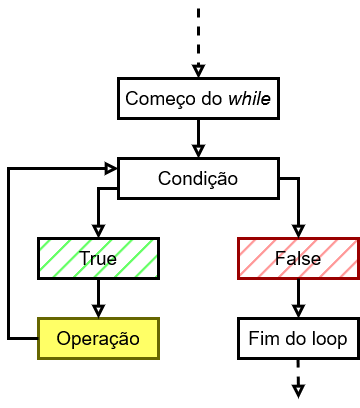

**Mais sobre os tópicos da aula**

- Vídeos
  - [Estruturas de seleção com if e else](https://www.youtube.com/watch?v=zouf7AkISR4), em Cursos Kane Chan
  - [Estrutura de repetição while](https://www.youtube.com/watch?v=VynNy4Ix9Fc), em DevMedia
- Leituras
  - [Comandos if](https://docs.python.org/pt-br/3.8/tutorial/controlflow.html#if-statements), em Python.org
  - [Comandos de decisão](https://www.inf.pucrs.br/pinho/PCB/ComandosDeDecisao/Decisao.htm), em Escola Politécnica - PUC-RS
  - [Python while: executar código com condição verdadeira](https://blog.betrybe.com/python/python-while/), em Betrybe

**Atividade 1**

Recentemente tem feito muito calor em algumas regiões do Brasil. Na minha categorização:

- Menos que 0º é congelante,
- De 0º a 10º é muito frio,
- De 10,1º a 17º é friozinho,
- De 17,1º a 24º é ameno,
- De 24,1º a 30º é calor,
- Acima de 30º é muito calor.

Escreva um programa que:

1. pede ao usuário a temperatura no momento (dica: use `input`),
2. retorne ao usuário a informação sobre a temperatura de acordo com a tabela acima.

**Atividade 2**

A brincadeira do "pim" ficou famosa no Programa do Silvio Santos: alguém da plateia é escolhida e deve contar até onde conseguir, mas trocando o número 4 e seus múltiplos pela palavra "pim".

> Um, dois, três, pim, cinco, seis, sete, pim...

Aqui um exemplo: https://www.youtube.com/watch?v=s6PCVq_ojto

Escreva um programa que:

1. pede ao usuário um número acima de entre 40 e 60 (dica: use `input`),
2. imprima na tela cada número, exceto 4 e seus múltiplos, que devem ser substituídos por "pim".